# 00_DataGathering

##### Authors: Diego Senso González, Luis Vaciero

##### 15 january 2021

##### Module: Machine Learning - Master's Degree in Data Science for Finance

## Objective

The purpose of this document is to show the obtention and treatment of the data from company Bicimad during 2020.

```python
%matplotlib inline
import matplotlib.pyplot as plt
import matplotlib.image as mpimg
from PIL import Image
```

### Annual usage database describing user journeys

of BiciMAD in 2020. It is used for a first exploratory analysis. More than 2 millions of observations or users make up this database. The data has have been downloaded from the OPENDATA portal of the EMT in Madrid, separated by months.

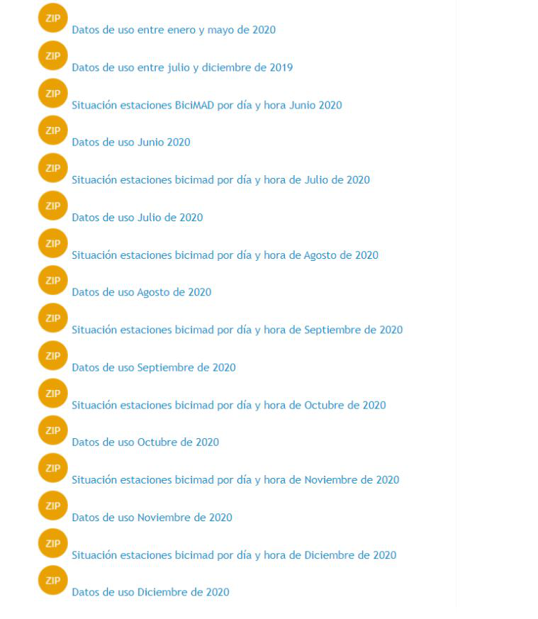

```python
img = Image.open("../img/CAPTURA.jpg")
img
```

### Bike station location by day and time in December 2020

Monthly database of December 2020. It is composed of variables that measure the number of bikes and bases available from each station for all days and hourly ranges of the month. 172 observations or stations make up this database. We use it to name and locate each of the stations that appear in the dataset of journeys made in 2020. OPENDATA of the EMT of Madrid.

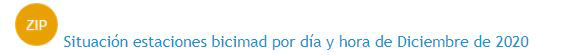

```python
img = Image.open("../img/estaciones.jpg")
img
```

### Data in Json

As Bicimad data are stored in Json files and there are variables that generate problems due to the format we must treat them before converting them to .csv and start dealing with them

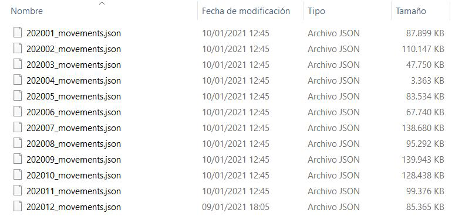

```python
img = Image.open("../img/json.jpg")
img
```

### Download Mongodb Compass to create a local server

When we open Mongodb Compass we create a localhost 27017 server that is stored in a data folder inside the disk. This will help us to be able to use Studio 3T

[figure not shown]

```python
img = Image.open("../img/mongodb.jpg")
img
```

[figure not shown]

```python
img = Image.open("../img/servidor.jpg")
img
```

## Download and use Studio 3T for the processing and conversion of .json to .csv files

[figure not shown]

```python
img = Image.open("../img/studio.jpg")
img
```

Once the local Mongodb Compass server is created we connect through Studio 3T and import the .json files to eliminate the track variable since it has subfields (a collection of features) and that's why it gives problems when converting it to .csv

[figure not shown]

```python
img = Image.open("../img/interfaz.jpg")
img
```

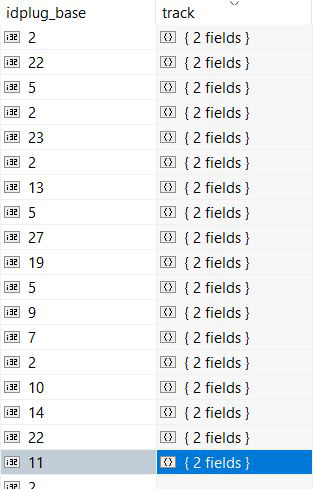

```python
img = Image.open("../img/track.jpg")
img
```

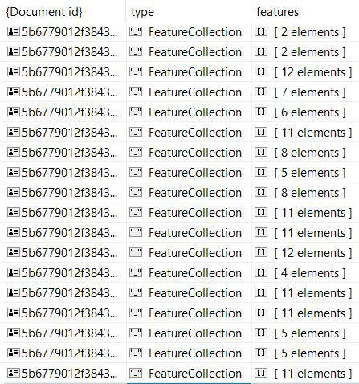

```python
img = Image.open("../img/track2.jpg")
img
```

[figure not shown]

```python
img = Image.open("../img/import.jpg")
img
```

With the data extracted in this way, we will go on to perform the EDA and create new datasets with the information we have.